# LINCS Signature MAE QC

Michael Tran

2026-04-30

This notebook demonstrates the structure and basic use of the final `MultiAssayExperiment` containing compound-level LINCS signatures, compound annotations, and cell-line annotations.

## Load the MAE

```r
mae <- readRDS(mae_path)

assay_names <- names(experiments(mae))
signature_se <- experiments(mae)[["signatures"]]
signature_mat <- assay(signature_se)

compound_metadata <- as.data.frame(metadata(mae)$Drug.Metadata) |>
  rownames_to_column("Compound.Key") |>
  as_tibble()

coldata <- as.data.frame(colData(mae)) |>
  as_tibble()

feature_metadata <- as.data.frame(rowData(signature_se)) |>
  as_tibble()

selected_gene_metadata <- as.data.frame(metadata(mae)$Selected.Gene.Metadata) |>
  as_tibble()

cell_line_metadata <- if ("Cell.Line.Metadata" %in% names(metadata(mae))) {
  as.data.frame(metadata(mae)$Cell.Line.Metadata) |>
    rownames_to_column("Cell.Line.Key") |>
    as_tibble()
} else {
  tibble()
}

mae
```

```
## A MultiAssayExperiment object of 1 listed
##  experiment with a user-defined name and respective class.
##  Containing an ExperimentList class object of length 1:
##  [1] signatures: SummarizedExperiment with 188 rows and 20788 columns
## Functionality:
##  experiments() - obtain the ExperimentList instance
##  colData() - the primary/phenotype DataFrame
##  sampleMap() - the sample coordination DataFrame
##  `$`, `[`, `[[` - extract colData columns, subset, or experiment
##  *Format() - convert into a long or wide DataFrame
##  assays() - convert ExperimentList to a SimpleList of matrices
##  exportClass() - save data to flat files
```

## Dataset Overview

```r
feature_type_counts <- feature_metadata |>
  count(LINCS.Feature.type, name = "features", sort = TRUE)

annotation_availability <- compound_metadata |>
  mutate(
    annotation_status = if_else(
      In.AnnotationDB,
      "AnnotationDB enriched",
      "No AnnotationDB match",
      missing = "No AnnotationDB match"
    )
  ) |>
  count(annotation_status, name = "compounds") |>
  mutate(
    fraction = compounds / sum(compounds),
    percent = scales::percent(fraction, accuracy = 0.1),
    label = paste0(
      annotation_status,
      "\n",
      scales::comma(compounds),
      " (",
      percent,
      ")"
    )
  )

assay_summary <- tibble(
  assay = assay_names,
  feature_type = "compound-level LINCS signature coefficients",
  assay_name = vapply(
    assay_names,
    \(assay_name) {
      paste(assayNames(experiments(mae)[[assay_name]]), collapse = ", ")
    },
    character(1)
  ),
  features = vapply(
    assay_names,
    \(assay_name) nrow(experiments(mae)[[assay_name]]),
    integer(1)
  ),
  compounds = vapply(
    assay_names,
    \(assay_name) ncol(experiments(mae)[[assay_name]]),
    integer(1)
  )
)

overview_tbl <- tibble(
  quantity = c(
    "Pipeline ID",
    "Pipeline version",
    "Experiments",
    "Assays",
    "Compounds in colData",
    "Drug metadata records",
    "Signature features",
    "Selected genes represented in metadata",
    "Median source signatures per compound",
    "Maximum source signatures per compound",
    "Compounds with PubChem CID",
    "Compounds without PubChem CID",
    "Cell line metadata records",
    "Cell lines in AnnotationDB"
  ),
  value = c(
    metadata(mae)$Pipeline$ID,
    metadata(mae)$Pipeline$Version,
    fmt_count(length(experiments(mae))),
    paste(assay_names, collapse = ", "),
    fmt_count(nrow(coldata)),
    fmt_count(nrow(compound_metadata)),
    fmt_count(nrow(signature_mat)),
    fmt_count(nrow(selected_gene_metadata)),
    fmt_count(stats::median(compound_metadata$LINCS.Signature.Count)),
    fmt_count(max(compound_metadata$LINCS.Signature.Count)),
    fmt_count(sum(!is.na(compound_metadata$Pubchem.CID))),
    fmt_count(sum(is.na(compound_metadata$Pubchem.CID))),
    fmt_count(nrow(cell_line_metadata)),
    fmt_count(
      if (nrow(cell_line_metadata) > 0) {
        sum(cell_line_metadata$In.AnnotationDB.CellLine, na.rm = TRUE)
      } else {
        0L
      }
    )
  )
)

kable(overview_tbl)
```

| quantity | value |
| --- | --- |
| Pipeline ID | lincs |
| Pipeline version | v2.0.0 |
| Experiments | 1 |
| Assays | signatures |
| Compounds in colData | 20,788 |
| Drug metadata records | 20,788 |
| Signature features | 188 |
| Selected genes represented in metadata | 978 |
| Median source signatures per compound | 5 |
| Maximum source signatures per compound | 5,384 |
| Compounds with PubChem CID | 20,349 |
| Compounds without PubChem CID | 439 |
| Cell line metadata records | 131 |
| Cell lines in AnnotationDB | 131 |

```r
kable(assay_summary)
```

| assay | feature_type | assay_name | features | compounds |
| --- | --- | --- | --- | --- |
| signatures | compound-level LINCS signature coefficients | values | 188 | 20788 |

This MAE contains one assay, `signatures`. Rows are LINCS signature features and columns are compounds keyed by `LINCS.CMap.Name`. The object is compound-level: each assay column summarizes the source LINCS signatures associated with one compound rather than one perturbation instance.

## Inspect the MAE Structure

The object layout is inspected directly below. The experiment container, assay names, compound-level metadata, sample map, and object-level metadata can all be accessed from the printed structure and the code shown in this section.

```r
mae
```

```
## A MultiAssayExperiment object of 1 listed
##  experiment with a user-defined name and respective class.
##  Containing an ExperimentList class object of length 1:
##  [1] signatures: SummarizedExperiment with 188 rows and 20788 columns
## Functionality:
##  experiments() - obtain the ExperimentList instance
##  colData() - the primary/phenotype DataFrame
##  sampleMap() - the sample coordination DataFrame
##  `$`, `[`, `[[` - extract colData columns, subset, or experiment
##  *Format() - convert into a long or wide DataFrame
##  assays() - convert ExperimentList to a SimpleList of matrices
##  exportClass() - save data to flat files
```

```r
experiments(mae)
```

```
## ExperimentList class object of length 1:
##  [1] signatures: SummarizedExperiment with 188 rows and 20788 columns
```

```r
colnames(colData(mae))
```

```
##  [1] "LINCS.CMap.Name"       "Pubchem.CID"           "InChIKey"
##  [4] "In.AnnotationDB"       "AnnotationDB.Name"     "AnnotationDB.SMILES"
##  [7] "LINCS.MOA"             "LINCS.Targets"         "LINCS.Aliases"
## [10] "AnnotationDB.Aliases"  "LINCS.Signature.Count" "LINCS.Gene.Count"
## [13] "LINCS.Feature.Count"
```

```r
head(as.data.frame(sampleMap(mae)))
```

```
##        assay           primary           colname
## 1 signatures            1-EBIO            1-EBIO
## 2 signatures 1-benzylimidazole 1-benzylimidazole
## 3 signatures    1-monopalmitin    1-monopalmitin
## 4 signatures 1-phenylbiguanide 1-phenylbiguanide
## 5 signatures           10-DEBC           10-DEBC
## 6 signatures             2-BFI             2-BFI
```

```r
names(metadata(mae))
```

```
## [1] "Pipeline"               "Selected.Gene.Metadata" "Cell.Line.Metadata"
## [4] "Drug.Metadata"
```

The `sampleMap` is one-to-one for this dataset: both `primary` and `colname` are `LINCS.CMap.Name`, and they point to the same compound columns in the `signatures` assay.

## Compound Metadata

```r
compound_metadata |>
  select(
    LINCS.CMap.Name,
    Pubchem.CID,
    InChIKey,
    In.AnnotationDB,
    AnnotationDB.Name,
    LINCS.MOA,
    LINCS.Targets,
    LINCS.Signature.Count
  ) |>
  slice_head(n = 8) |>
  kable()
```

| LINCS.CMap.Name | Pubchem.CID | InChIKey | In.AnnotationDB | AnnotationDB.Name | LINCS.MOA | LINCS.Targets | LINCS.Signature.Count |
| --- | --- | --- | --- | --- | --- | --- | --- |
| 1-EBIO | 82320 | CXUCKELNYMZTRT-UHFFFAOYSA-N | TRUE | 1-Ebio | NA | NA | 1 |
| 1-benzylimidazole | 77918 | KKKDZZRICRFGSD-UHFFFAOYSA-N | TRUE | 1-Benzylimidazole | NA | NA | 12 |
| 1-monopalmitin | 14900 | QHZLMUACJMDIAE-UHFFFAOYSA-N | TRUE | 1-Monopalmitin | P-glycoprotein inhibitor | ABCB1 | 7 |
| 1-phenylbiguanide | 4780 | CUQCMXFWIMOWRP-UHFFFAOYSA-N | TRUE | Phenylbiguanide | NA | NA | 7 |
| 10-DEBC | 10521421 | GYBXAGDWMCJZJK-UHFFFAOYSA-N | TRUE | 4-(2-Chloro-10h-Phenoxazin-10-Yl)-N,N-Diethylbutan-1-Amine | Akt inhibitor | PIM1 | 117 |
| 2-BFI | 3080926 | YTJOHEUHUVBKSB-UHFFFAOYSA-N | TRUE | 2-(2-Benzofuranyl)-2-imidazoline | NA | NA | 1 |
| 2-PMDQ | 6081682 | ONSOQRPYFKDOEB-UHFFFAOYSA-N | TRUE | NA | Adrenergic receptor antagonist | ADRA1A | 1 |
| 2-aminobenzenesulfonamide | 72894 | YAZSBRQTAHVVGE-UHFFFAOYSA-N | TRUE | 2-Aminobenzenesulfonamide | NA | NA | 4 |

The main fields commonly used in downstream analysis are:

- `LINCS.CMap.Name`: the compound identifier used as the MAE primary key and as the assay column name.
- `Pubchem.CID`: the PubChem compound identifier used to join back to the base harmonized drug dataset.
- `InChIKey`: the structure-level identifier retained from source and AnnotationDB processing.
- `In.AnnotationDB`: whether the compound mapped to AnnotationDB metadata.
- `AnnotationDB.Name` and `AnnotationDB.SMILES`: the minimal AnnotationDB metadata carried with this dataset.
- `LINCS.MOA`, `LINCS.Targets`, and `LINCS.Aliases`: source LINCS compound annotations.
- `LINCS.Signature.Count`: the number of source LINCS signatures contributing to the compound-level signature.

```r
metadata_completeness <- compound_metadata |>
  summarise(
    across(
      c(
        Pubchem.CID,
        InChIKey,
        AnnotationDB.Name,
        AnnotationDB.SMILES,
        LINCS.MOA,
        LINCS.Targets,
        LINCS.Aliases,
        AnnotationDB.Aliases
      ),
      \(value) sum(is_present(value))
    )
  ) |>
  pivot_longer(
    cols = everything(),
    names_to = "field",
    values_to = "present"
  ) |>
  mutate(
    missing = nrow(compound_metadata) - present,
    percent_present = fmt_percent(present / nrow(compound_metadata))
  ) |>
  arrange(desc(present))

kable(metadata_completeness)
```

| field | present | missing | percent_present |
| --- | --- | --- | --- |
| InChIKey | 20788 | 0 | 100.0% |
| Pubchem.CID | 20349 | 439 | 97.9% |
| AnnotationDB.SMILES | 20349 | 439 | 97.9% |
| AnnotationDB.Aliases | 20349 | 439 | 97.9% |
| AnnotationDB.Name | 20261 | 527 | 97.5% |
| LINCS.MOA | 2527 | 18261 | 12.2% |
| LINCS.Targets | 2527 | 18261 | 12.2% |
| LINCS.Aliases | 603 | 20185 | 2.9% |

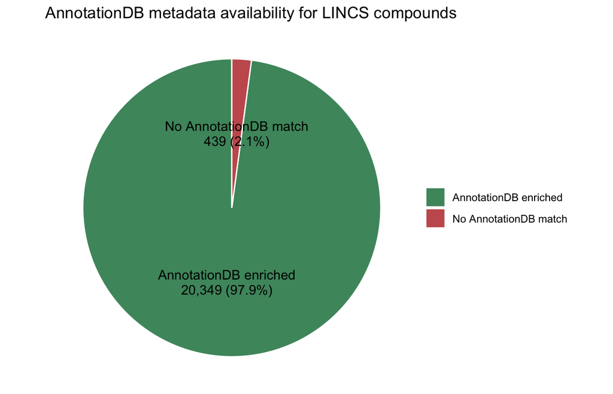

```r
ggplot(
  annotation_availability,
  aes(x = "", y = fraction, fill = annotation_status)
) +
  geom_col(width = 1, color = "white") +
  geom_text(
    aes(label = label),
    position = position_stack(vjust = 0.5),
    lineheight = 0.95
  ) +
  coord_polar(theta = "y") +
  scale_fill_manual(values = c("#4C956C", "#C75C5C")) +
  labs(
    title = "AnnotationDB metadata availability for LINCS compounds",
    fill = NULL
  ) +
  theme_void()
```

## Cell Line Metadata

LINCS cell lines are represented as `cell_iname` feature rows in the `signatures` assay rather than as MAE samples. Cell-line metadata is stored in `metadata(mae)$Cell.Line.Metadata`, joined into the corresponding rowData rows, and exported as `cell_line_metadata.tsv`.

```r
cell_line_summary <- tibble(
  quantity = c(
    "Cell line metadata records",
    "Cell lines with Cellosaurus ID",
    "Cell lines in AnnotationDB",
    "Cell-line assay features"
  ),
  value = c(
    fmt_count(nrow(cell_line_metadata)),
    fmt_count(
      if (nrow(cell_line_metadata) > 0) {
        sum(is_present(cell_line_metadata$Cellosaurus.ID))
      } else {
        0L
      }
    ),
    fmt_count(
      if (nrow(cell_line_metadata) > 0) {
        sum(cell_line_metadata$In.AnnotationDB.CellLine, na.rm = TRUE)
      } else {
        0L
      }
    ),
    fmt_count(sum(feature_metadata$LINCS.Feature.type == "cell_iname"))
  )
)

kable(cell_line_summary)
```

| quantity | value |
| --- | --- |
| Cell line metadata records | 131 |
| Cell lines with Cellosaurus ID | 131 |
| Cell lines in AnnotationDB | 131 |
| Cell-line assay features | 131 |

```r
cell_line_metadata |>
  select(
    any_of(
      c(
        "LINCS.Cell.Name",
        "Cellosaurus.ID",
        "In.AnnotationDB.CellLine",
        "Cell.Line.Name",
        "LINCS.CCLE.Name",
        "LINCS.Primary.Disease"
      )
    )
  ) |>
  slice_head(n = 8) |>
  kable()
```

| LINCS.Cell.Name | Cellosaurus.ID | In.AnnotationDB.CellLine | Cell.Line.Name | LINCS.CCLE.Name | LINCS.Primary.Disease |
| --- | --- | --- | --- | --- | --- |
| 22RV1 | CVCL_1045 | TRUE | 22Rv1 | 22RV1_PROSTATE | prostate cancer |
| 5637 | CVCL_0126 | TRUE | 5637 | 5637_URINARY_TRACT | bladder cancer |
| A204 | CVCL_1058 | TRUE | A-204 | A204_SOFT_TISSUE | embryonal cancer |
| A375 | CVCL_0132 | TRUE | A-375 | A375_SKIN | skin cancer |
| A549 | CVCL_0023 | TRUE | A-549 | A549_LUNG | lung cancer |
| A673 | CVCL_0080 | TRUE | A-673 | A673_BONE | bone cancer |
| AGS | CVCL_0139 | TRUE | AGS | AGS_STOMACH | gastric cancer |
| AN3CA | CVCL_0028 | TRUE | AN3-CA | AN3CA_ENDOMETRIUM | endometrial cancer |

## Signature Coverage

The source LINCS data can contain many signatures for the same compound. The compound-level assay stores one signature column per compound while retaining the number of source signatures in `LINCS.Signature.Count`.

```r
signature_count_tbl <- compound_metadata |>
  summarise(
    compounds = n(),
    minimum = min(LINCS.Signature.Count),
    q1 = stats::quantile(LINCS.Signature.Count, 0.25),
    median = stats::median(LINCS.Signature.Count),
    mean = mean(LINCS.Signature.Count),
    q3 = stats::quantile(LINCS.Signature.Count, 0.75),
    maximum = max(LINCS.Signature.Count)
  ) |>
  mutate(across(everything(), fmt_number))

kable(signature_count_tbl)
```

| compounds | minimum | q1 | median | mean | q3 | maximum |
| --- | --- | --- | --- | --- | --- | --- |
| 20,788 | 1 | 3 | 5 | 23.48 | 12 | 5,384 |

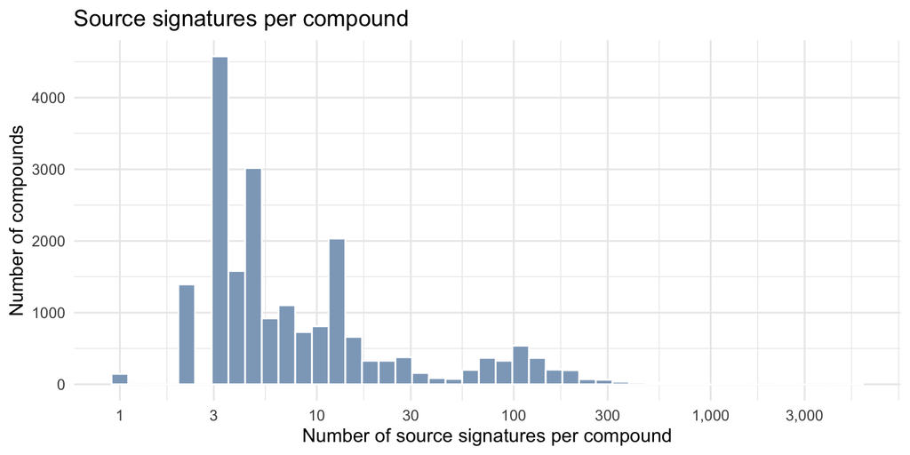

```r
axis_values <- c(1, 3, 10, 30, 100, 300, 1000, 3000)

ggplot(
  compound_metadata,
  aes(x = log10(LINCS.Signature.Count))
) +
  geom_histogram(bins = 45, fill = "#8EA8C3", color = "white") +
  scale_x_continuous(
    breaks = log10(axis_values),
    labels = scales::comma(axis_values)
  ) +
  labs(
    title = "Source signatures per compound",
    x = "Number of source signatures per compound",
    y = "Number of compounds"
  )
```

```r
compound_metadata |>
  arrange(desc(LINCS.Signature.Count), LINCS.CMap.Name) |>
  select(
    LINCS.CMap.Name,
    Pubchem.CID,
    In.AnnotationDB,
    LINCS.MOA,
    LINCS.Targets,
    LINCS.Signature.Count
  ) |>
  slice_head(n = 12) |>
  kable()
```

| LINCS.CMap.Name | Pubchem.CID | In.AnnotationDB | LINCS.MOA | LINCS.Targets | LINCS.Signature.Count |
| --- | --- | --- | --- | --- | --- |
| bortezomib | 387447 | TRUE | Proteasome inhibitor\|NFKB pathway inhibitor | PSMB1\|PSMB2\|PSMB5 | 5384 |
| MG-132 | 462382 | TRUE | Proteasome inhibitor | PSMB1 | 5301 |
| vorinostat | 5311 | TRUE | HDAC inhibitor | HDAC6\|HDAC1\|HDAC2\|HDAC8\|HDAC3 | 2350 |
| wortmannin | 5691 | TRUE | PI3K inhibitor | PIK3CA\|PIK3CG\|PLK1 | 1349 |
| mitoxantrone | 4212 | TRUE | Topoisomerase inhibitor | TOP2A | 1302 |
| geldanamycin | 5288382 | TRUE | HSP inhibitor | HSP90AA1 | 1295 |
| sirolimus | 5282071 | TRUE | MTOR inhibitor | FKBP1A\|MTOR | 1246 |
| BRD-A19037878 | 6376322 | TRUE | NA | NA | 1193 |
| PD-0325901 | 9826528 | TRUE | MEK inhibitor\|MAP kinase inhibitor\|Protein kinase inhibitor | MAP2K1 | 1025 |
| dasatinib | 3062316 | TRUE | KIT inhibitor\|Src inhibitor\|PDGFR inhibitor\|Ephrin inhibitor\|Abl kinase inhibitor\|Tyrosine kinase inhibitor | EPHA2\|ABL1\|FYN\|KIT\|LCK\|LYN\|PDGFRB\|BCR\|SRC\|YES1 | 910 |
| tanespimycin | 6505803 | TRUE | HSP inhibitor | HSP90AA1 | 820 |
| troglitazone | 5591 | TRUE | Insulin sensitizer\|PPAR receptor agonist | PPARG | 786 |

## Compound Annotation Landscape

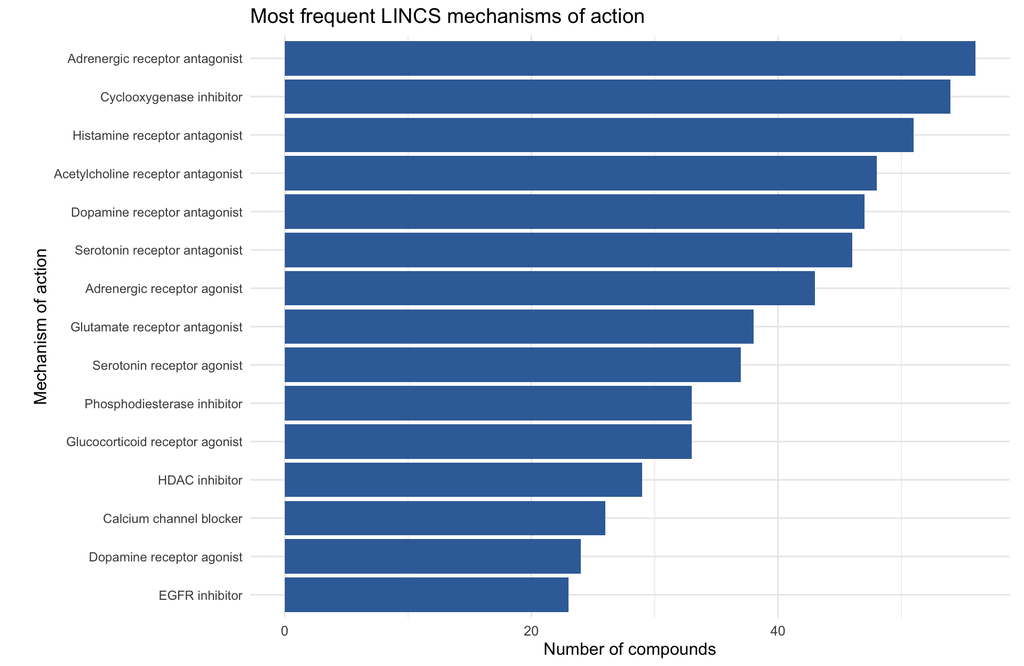

```r
moa_summary <- compound_metadata |>
  filter(is_present(LINCS.MOA)) |>
  count(LINCS.MOA, name = "compounds", sort = TRUE) |>
  slice_head(n = 15)

ggplot(
  moa_summary,
  aes(
    x = compounds,
    y = reorder(stringr::str_wrap(LINCS.MOA, width = 38), compounds)
  )
) +
  geom_col(fill = "#3B6EA8") +
  labs(
    title = "Most frequent LINCS mechanisms of action",
    x = "Number of compounds",
    y = "Mechanism of action"
  ) +
  theme(
    axis.text.y = element_text(size = 9),
    plot.margin = margin(5.5, 10, 5.5, 24)
  )
```

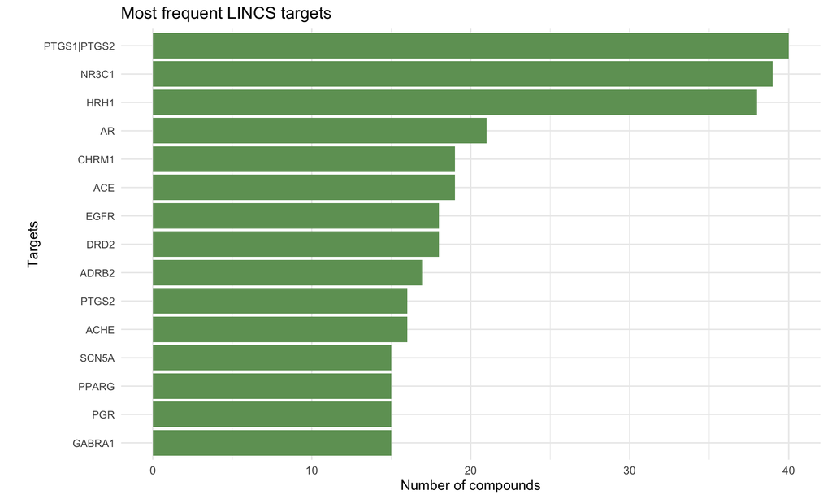

```r
target_summary <- compound_metadata |>
  filter(is_present(LINCS.Targets)) |>
  count(LINCS.Targets, name = "compounds", sort = TRUE) |>
  slice_head(n = 15)

ggplot(
  target_summary,
  aes(
    x = compounds,
    y = reorder(stringr::str_wrap(LINCS.Targets, width = 38), compounds)
  )
) +
  geom_col(fill = "#6E9F64") +
  labs(
    title = "Most frequent LINCS targets",
    x = "Number of compounds",
    y = "Targets"
  ) +
  theme(
    axis.text.y = element_text(size = 9),
    plot.margin = margin(5.5, 10, 5.5, 24)
  )
```

## Signature Assay

```r
feature_metadata |>
  slice_head(n = 12) |>
  kable()
```

| Feature.ID | LINCS.Feature.index | LINCS.Feature.name | LINCS.Feature.type | LINCS.Feature.value | Cellosaurus.ID | In.AnnotationDB.CellLine | Cell.Line.Name |
| --- | --- | --- | --- | --- | --- | --- | --- |
| pert_time | 0 | pert_time | scalar | pert_time | NA | NA | NA |
| pert_dose | 1 | pert_dose | scalar | pert_dose | NA | NA | NA |
| bead_batch:b1 | 2 | bead_batch:b1 | bead_batch | b1 | NA | NA | NA |
| bead_batch:b10 | 3 | bead_batch:b10 | bead_batch | b10 | NA | NA | NA |
| bead_batch:b11 | 4 | bead_batch:b11 | bead_batch | b11 | NA | NA | NA |
| bead_batch:b12 | 5 | bead_batch:b12 | bead_batch | b12 | NA | NA | NA |
| bead_batch:b13 | 6 | bead_batch:b13 | bead_batch | b13 | NA | NA | NA |
| bead_batch:b14 | 7 | bead_batch:b14 | bead_batch | b14 | NA | NA | NA |
| bead_batch:b15 | 8 | bead_batch:b15 | bead_batch | b15 | NA | NA | NA |
| bead_batch:b16 | 9 | bead_batch:b16 | bead_batch | b16 | NA | NA | NA |
| bead_batch:b17 | 10 | bead_batch:b17 | bead_batch | b17 | NA | NA | NA |
| bead_batch:b18 | 11 | bead_batch:b18 | bead_batch | b18 | NA | NA | NA |

```r
kable(feature_type_counts)
```

| LINCS.Feature.type | features |
| --- | --- |
| cell_iname | 131 |
| bead_batch | 55 |
| scalar | 2 |

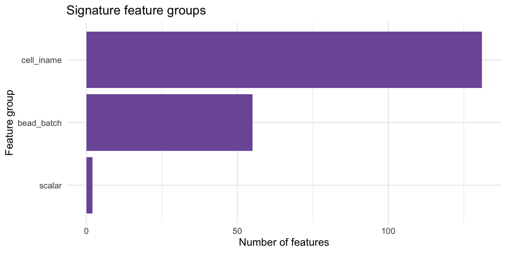

```r
ggplot(
  feature_type_counts,
  aes(x = reorder(LINCS.Feature.type, features), y = features)
) +
  geom_col(fill = "#7D5BA6") +
  labs(
    title = "Signature feature groups",
    x = "Feature group",
    y = "Number of features"
  ) +
  coord_flip()
```

The `signatures` assay stores numeric coefficients. Most entries are zero, so the next summaries show both overall matrix completeness and non-zero coefficient behavior.

```r
assay_values <- as.vector(signature_mat)
nonzero_values <- assay_values[is.finite(assay_values) & assay_values != 0]

assay_quality_tbl <- tibble(
  quantity = c(
    "Matrix rows",
    "Matrix columns",
    "Matrix entries",
    "Missing entries",
    "Non-finite entries",
    "Zero fraction",
    "Non-zero entries",
    "Minimum coefficient",
    "Median coefficient",
    "Mean coefficient",
    "Maximum coefficient"
  ),
  value = c(
    fmt_count(nrow(signature_mat)),
    fmt_count(ncol(signature_mat)),
    fmt_count(length(assay_values)),
    fmt_count(sum(is.na(assay_values))),
    fmt_count(sum(!is.finite(assay_values))),
    fmt_percent(mean(assay_values == 0, na.rm = TRUE)),
    fmt_count(length(nonzero_values)),
    fmt_number(min(assay_values, na.rm = TRUE), 4),
    fmt_number(stats::median(assay_values, na.rm = TRUE), 4),
    fmt_number(mean(assay_values, na.rm = TRUE), 4),
    fmt_number(max(assay_values, na.rm = TRUE), 4)
  )
)

kable(assay_quality_tbl)
```

| quantity | value |
| --- | --- |
| Matrix rows | 188 |
| Matrix columns | 20,788 |
| Matrix entries | 3,908,144 |
| Missing entries | 0 |
| Non-finite entries | 0 |
| Zero fraction | 88.1% |
| Non-zero entries | 464,394 |
| Minimum coefficient | 0 |
| Median coefficient | 0 |
| Mean coefficient | 0.0325 |
| Maximum coefficient | 1,141.524 |

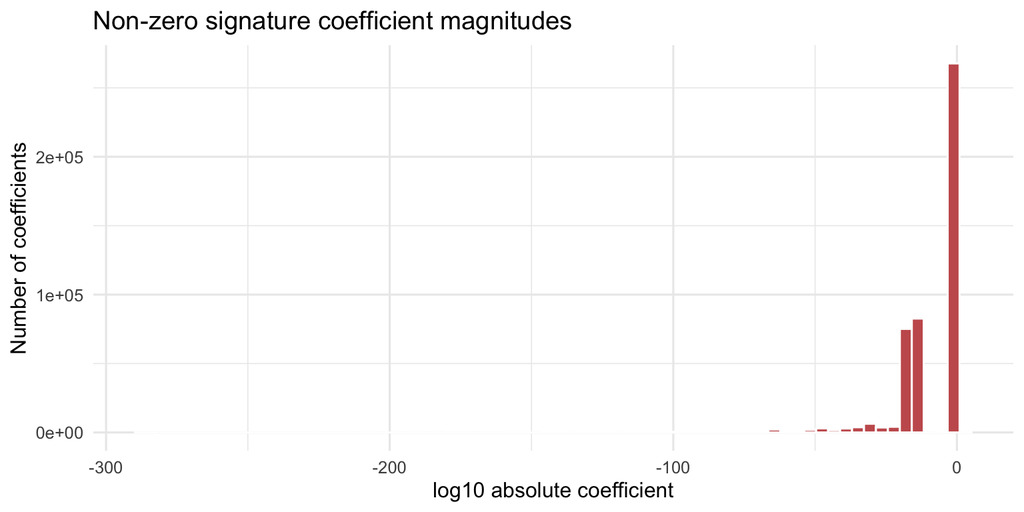

```r
tibble(log10_abs_coefficient = log10(abs(nonzero_values))) |>
  ggplot(aes(x = log10_abs_coefficient)) +
  geom_histogram(bins = 70, fill = "#C75C5C", color = "white") +
  labs(
    title = "Non-zero signature coefficient magnitudes",
    x = "log10 absolute coefficient",
    y = "Number of coefficients"
  )
```

```r
feature_stats <- tibble(
  Feature.ID = rownames(signature_mat),
  Mean = rowMeans(signature_mat),
  SD = apply(signature_mat, 1, stats::sd),
  Zero.Fraction = rowMeans(signature_mat == 0)
) |>
  left_join(feature_metadata, by = "Feature.ID") |>
  arrange(desc(SD))

kable(
  feature_stats |>
    select(
      Feature.ID,
      LINCS.Feature.type,
      LINCS.Feature.value,
      Mean,
      SD,
      Zero.Fraction
    ) |>
    mutate(
      Mean = fmt_number(Mean, 4),
      SD = fmt_number(SD, 4),
      Zero.Fraction = fmt_percent(Zero.Fraction)
    ) |>
    slice_head(n = 15)
)
```

| Feature.ID | LINCS.Feature.type | LINCS.Feature.value | Mean | SD | Zero.Fraction |
| --- | --- | --- | --- | --- | --- |
| bead_batch:b10 | bead_batch | b10 | 0.1208 | 10.2921 | 49.4% |
| bead_batch:b11 | bead_batch | b11 | 0.0821 | 7.9373 | 55.1% |
| cell_iname:VCAP | cell_iname | VCAP | 0.3594 | 3.8958 | 25.3% |
| cell_iname:PC3 | cell_iname | PC3 | 0.3409 | 3.7719 | 42.5% |
| pert_dose | scalar | pert_dose | 0.0984 | 2.7288 | 0.0% |
| bead_batch:b2 | bead_batch | b2 | 0.1359 | 2.4490 | 38.8% |
| bead_batch:f2b4 | bead_batch | f2b4 | 0.0932 | 2.4458 | 79.6% |
| cell_iname:A375 | cell_iname | A375 | 0.3357 | 1.8535 | 40.0% |
| cell_iname:HT29 | cell_iname | HT29 | 0.3305 | 1.8529 | 43.9% |
| cell_iname:MCF7 | cell_iname | MCF7 | 0.3198 | 1.8515 | 43.0% |
| cell_iname:A549 | cell_iname | A549 | 0.3546 | 1.8499 | 35.3% |
| bead_batch:b7 | bead_batch | b7 | 0.0313 | 0.9836 | 84.7% |
| bead_batch:f1b6 | bead_batch | f1b6 | 0.2540 | 0.4232 | 46.9% |
| cell_iname:HCC515 | cell_iname | HCC515 | 0.1602 | 0.3018 | 71.8% |
| cell_iname:HEPG2 | cell_iname | HEPG2 | 0.1372 | 0.2848 | 76.5% |

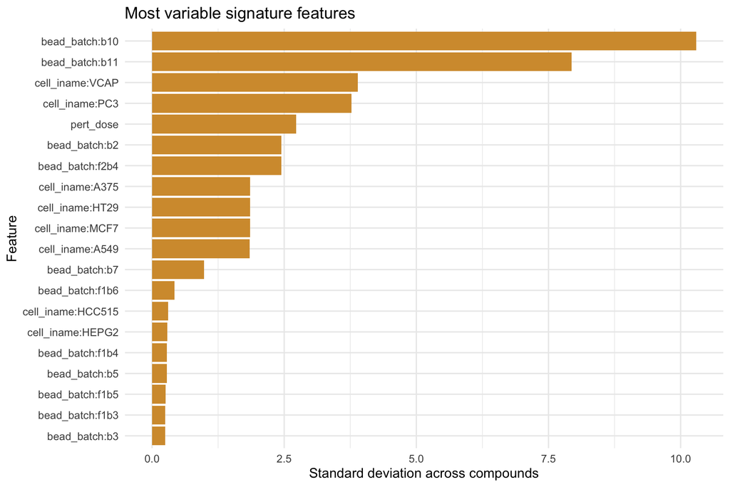

```r
top_feature_variability <- feature_stats |>
  slice_head(n = 20)

ggplot(
  top_feature_variability,
  aes(x = SD, y = reorder(Feature.ID, SD))
) +
  geom_col(fill = "#D49A3A") +
  labs(
    title = "Most variable signature features",
    x = "Standard deviation across compounds",
    y = "Feature"
  )
```

## UMAP View

A UMAP of the compound-by-feature matrix provides a compact view of global signature structure. The plot below uses a reproducible sample of compounds and colors points by the number of source signatures contributing to each compound-level column.

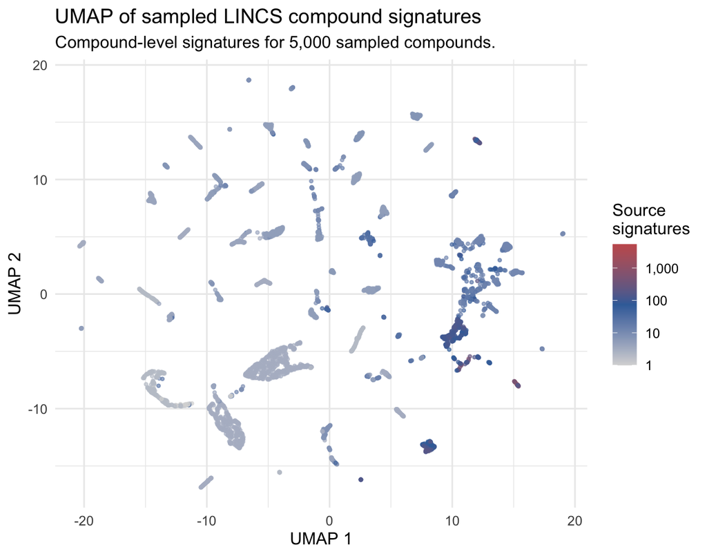

```r
set.seed(20260430)

variable_features <- feature_stats |>
  filter(is.finite(SD), SD > 0) |>
  pull(Feature.ID)

umap_sample_n <- min(5000L, ncol(signature_mat))

umap_compounds <- compound_metadata |>
  filter(LINCS.CMap.Name %in% colnames(signature_mat)) |>
  slice_sample(n = umap_sample_n)

umap_signatures <- signature_mat[
  variable_features,
  umap_compounds$LINCS.CMap.Name,
  drop = FALSE
]

umap_input <- scale(t(umap_signatures))
umap_input[is.na(umap_input)] <- 0

umap_layout <- uwot::umap(
  umap_input,
  n_neighbors = 15,
  min_dist = 0.2,
  metric = "cosine",
  n_threads = 1,
  n_sgd_threads = 1,
  verbose = FALSE
)

umap_tbl <- as_tibble(umap_layout, .name_repair = \(x) c("UMAP1", "UMAP2")) |>
  bind_cols(
    umap_compounds |>
      select(
        LINCS.CMap.Name,
        LINCS.Signature.Count,
        In.AnnotationDB
      )
  )

ggplot(
  umap_tbl,
  aes(
    x = UMAP1,
    y = UMAP2,
    color = LINCS.Signature.Count
  )
) +
  geom_point(alpha = 0.65, size = 0.8) +
  scale_color_gradientn(
    colors = c("#D8D8D8", "#3B6EA8", "#C75C5C"),
    trans = "log10",
    labels = scales::comma
  ) +
  labs(
    title = "UMAP of sampled LINCS compound signatures",
    subtitle = paste0(
      "Compound-level signatures for ",
      scales::comma(nrow(umap_tbl)),
      " sampled compounds."
    ),
    x = "UMAP 1",
    y = "UMAP 2",
    color = "Source\nsignatures"
  )
```

## High-Variance Feature Snapshot

This heatmap shows the most variable signature features across the compounds with the largest number of contributing source signatures. Values are scaled by feature for visualization.

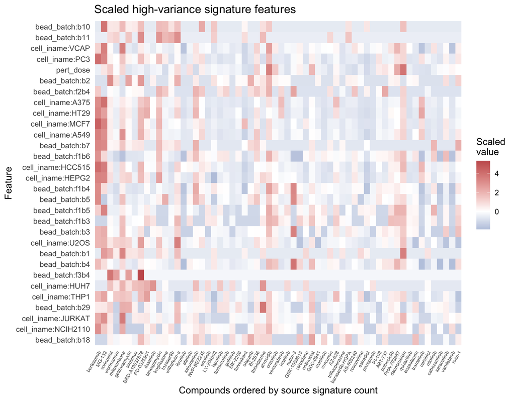

```r
top_heatmap_features <- feature_stats |>
  slice_head(n = 30) |>
  pull(Feature.ID)

top_heatmap_compounds <- compound_metadata |>
  arrange(desc(LINCS.Signature.Count), LINCS.CMap.Name) |>
  slice_head(n = 60) |>
  pull(LINCS.CMap.Name)

heatmap_mat <- signature_mat[
  top_heatmap_features,
  top_heatmap_compounds,
  drop = FALSE
]
heatmap_scaled <- t(scale(t(heatmap_mat)))
heatmap_scaled[!is.finite(heatmap_scaled)] <- 0

heatmap_tbl <- as.data.frame(heatmap_scaled) |>
  rownames_to_column("Feature.ID") |>
  as_tibble() |>
  pivot_longer(
    cols = -Feature.ID,
    names_to = "LINCS.CMap.Name",
    values_to = "Scaled.Value"
  ) |>
  mutate(
    Feature.ID = factor(Feature.ID, levels = rev(top_heatmap_features)),
    LINCS.CMap.Name = factor(
      LINCS.CMap.Name,
      levels = top_heatmap_compounds
    )
  )

ggplot(
  heatmap_tbl,
  aes(x = LINCS.CMap.Name, y = Feature.ID, fill = Scaled.Value)
) +
  geom_tile() +
  scale_fill_gradient2(
    low = "#3B6EA8",
    mid = "white",
    high = "#C75C5C",
    midpoint = 0
  ) +
  labs(
    title = "Scaled high-variance signature features",
    x = "Compounds ordered by source signature count",
    y = "Feature",
    fill = "Scaled\nvalue"
  ) +
  theme(
    axis.text.x = element_text(angle = 60, hjust = 1, size = 6),
    panel.grid = element_blank()
  )
```

Feature rows are coefficients from the compound-level signature model. Scalar rows such as `pert_dose` and `pert_time` capture treatment dose and time effects, `bead_batch:*` rows capture source batch effects, and `cell_iname:*` rows capture cell-line-associated effects. Colours are scaled within each feature row, so they are useful for comparing compounds within a feature, not for comparing absolute magnitudes across different feature rows.

## Basic Access Patterns

The MAE can be used directly as an analysis-ready compound signature matrix. Most analyses will either use the assay matrix in feature-by-compound form or transpose it to compound-by-feature form for modeling.

```r
example_compound <- compound_metadata |>
  filter(In.AnnotationDB) |>
  arrange(desc(LINCS.Signature.Count), LINCS.CMap.Name) |>
  slice(1) |>
  pull(LINCS.CMap.Name)

example_metadata <- compound_metadata |>
  filter(LINCS.CMap.Name == example_compound) |>
  select(
    LINCS.CMap.Name,
    Pubchem.CID,
    InChIKey,
    AnnotationDB.Name,
    LINCS.MOA,
    LINCS.Targets,
    LINCS.Signature.Count
  )

kable(example_metadata)
```

| LINCS.CMap.Name | Pubchem.CID | InChIKey | AnnotationDB.Name | LINCS.MOA | LINCS.Targets | LINCS.Signature.Count |
| --- | --- | --- | --- | --- | --- | --- |
| bortezomib | 387447 | GXJABQQUPOEUTA-RDJZCZTQSA-N | Bortezomib | Proteasome inhibitor\|NFKB pathway inhibitor | PSMB1\|PSMB2\|PSMB5 | 5384 |

```r
example_signature <- tibble(
  Feature.ID = rownames(signature_mat),
  coefficient = signature_mat[, example_compound]
) |>
  left_join(feature_metadata, by = "Feature.ID") |>
  arrange(desc(abs(coefficient))) |>
  select(
    Feature.ID,
    LINCS.Feature.type,
    LINCS.Feature.value,
    coefficient
  ) |>
  slice_head(n = 12)

kable(example_signature)
```

| Feature.ID | LINCS.Feature.type | LINCS.Feature.value | coefficient |
| --- | --- | --- | --- |
| cell_iname:SKES1 | cell_iname | SKES1 | 2.903178 |
| cell_iname:MDST8 | cell_iname | MDST8 | 2.895725 |
| bead_batch:b43 | bead_batch | b43 | 2.693052 |
| cell_iname:SKM1 | cell_iname | SKM1 | 2.650970 |
| cell_iname:NALM6 | cell_iname | NALM6 | 2.573592 |
| cell_iname:NCIH596 | cell_iname | NCIH596 | 2.548687 |
| cell_iname:JHUEM2 | cell_iname | JHUEM2 | 2.547565 |
| cell_iname:LOVO | cell_iname | LOVO | 2.503753 |
| cell_iname:YH13 | cell_iname | YH13 | 2.486437 |
| cell_iname:SKMEL28 | cell_iname | SKMEL28 | 2.481146 |
| cell_iname:NCIH2073 | cell_iname | NCIH2073 | 2.477228 |
| cell_iname:TC32 | cell_iname | TC32 | 2.458383 |

```r
egfr_compounds <- compound_metadata |>
  filter(grepl("EGFR", LINCS.Targets, fixed = TRUE)) |>
  pull(LINCS.CMap.Name)

egfr_signatures <- signature_mat[, egfr_compounds, drop = FALSE]

tibble(
  subset = "Compounds with EGFR in LINCS.Targets",
  compounds = length(egfr_compounds),
  features = nrow(egfr_signatures)
) |>
  kable()
```

| subset | compounds | features |
| --- | --- | --- |
| Compounds with EGFR in LINCS.Targets | 36 | 188 |

```r
modeling_matrix <- t(signature_mat)

tibble(
  object = c("feature_by_compound_matrix", "compound_by_feature_matrix"),
  rows = c(nrow(signature_mat), nrow(modeling_matrix)),
  columns = c(ncol(signature_mat), ncol(modeling_matrix))
) |>
  mutate(
    rows = fmt_count(rows),
    columns = fmt_count(columns)
  ) |>
  kable()
```

| object | rows | columns |
| --- | --- | --- |
| feature_by_compound_matrix | 188 | 20,788 |
| compound_by_feature_matrix | 20,788 | 188 |

The compound-by-feature matrix is typically the convenient orientation for machine learning or clustering workflows, while the feature-by-compound matrix matches the stored `SummarizedExperiment` assay orientation.